# Risk Factor Analysis

## Outcome Variable

**Outcome Variable:** wast_rec90d

## Predictor Variables

**Intervention Variable:** hdlvry

**Adjustment Set:**

- arm
- sex
- W_mage
- meducyrs
- feducyrs
- hhwealth_quart
- hfoodsec
- W_nrooms
- brthmon
- impfloor
- impsan
- delta_W_mage
- delta_meducyrs
- delta_feducyrs
- delta_hhwealth_quart
- delta_hfoodsec
- delta_W_nrooms
- delta_brthmon
- delta_impfloor
- delta_impsan

## Stratifying Variables

The analysis was stratified on these variable(s):

- agecat
- studyid
- country

## Data Summary

| agecat | studyid | country | hdlvry | wast_rec90d | n_cell | n |
| --- | --- | --- | --- | --- | --- | --- |
| 0-24 months | ki1000108-CMC-V-BCS-2002 | INDIA | 0 | 0 | 115 | 322 |
| 0-24 months | ki1000108-CMC-V-BCS-2002 | INDIA | 0 | 1 | 200 | 322 |
| 0-24 months | ki1000108-CMC-V-BCS-2002 | INDIA | 1 | 0 | 4 | 322 |
| 0-24 months | ki1000108-CMC-V-BCS-2002 | INDIA | 1 | 1 | 3 | 322 |
| 0-24 months | ki1000108-IRC | INDIA | 0 | 0 | 159 | 395 |
| 0-24 months | ki1000108-IRC | INDIA | 0 | 1 | 227 | 395 |
| 0-24 months | ki1000108-IRC | INDIA | 1 | 0 | 3 | 395 |
| 0-24 months | ki1000108-IRC | INDIA | 1 | 1 | 6 | 395 |
| 0-24 months | ki1000109-EE | PAKISTAN | 0 | 0 | 194 | 510 |
| 0-24 months | ki1000109-EE | PAKISTAN | 0 | 1 | 144 | 510 |
| 0-24 months | ki1000109-EE | PAKISTAN | 1 | 0 | 102 | 510 |
| 0-24 months | ki1000109-EE | PAKISTAN | 1 | 1 | 70 | 510 |
| 0-24 months | ki1000304b-SAS-CompFeed | INDIA | 0 | 0 | 34 | 675 |
| 0-24 months | ki1000304b-SAS-CompFeed | INDIA | 0 | 1 | 30 | 675 |
| 0-24 months | ki1000304b-SAS-CompFeed | INDIA | 1 | 0 | 386 | 675 |
| 0-24 months | ki1000304b-SAS-CompFeed | INDIA | 1 | 1 | 225 | 675 |
| 0-24 months | ki1000304b-SAS-FoodSuppl | INDIA | 0 | 0 | 40 | 234 |
| 0-24 months | ki1000304b-SAS-FoodSuppl | INDIA | 0 | 1 | 0 | 234 |
| 0-24 months | ki1000304b-SAS-FoodSuppl | INDIA | 1 | 0 | 181 | 234 |
| 0-24 months | ki1000304b-SAS-FoodSuppl | INDIA | 1 | 1 | 13 | 234 |
| 0-24 months | ki1017093b-PROVIDE | BANGLADESH | 0 | 0 | 94 | 307 |
| 0-24 months | ki1017093b-PROVIDE | BANGLADESH | 0 | 1 | 132 | 307 |
| 0-24 months | ki1017093b-PROVIDE | BANGLADESH | 1 | 0 | 34 | 307 |
| 0-24 months | ki1017093b-PROVIDE | BANGLADESH | 1 | 1 | 47 | 307 |
| 0-24 months | ki1017093c-NIH-Crypto | BANGLADESH | 0 | 0 | 79 | 311 |
| 0-24 months | ki1017093c-NIH-Crypto | BANGLADESH | 0 | 1 | 139 | 311 |
| 0-24 months | ki1017093c-NIH-Crypto | BANGLADESH | 1 | 0 | 38 | 311 |
| 0-24 months | ki1017093c-NIH-Crypto | BANGLADESH | 1 | 1 | 55 | 311 |
| 0-24 months | ki1066203-TanzaniaChild2 | TANZANIA, UNITED REPUBLIC OF | 0 | 0 | 250 | 682 |
| 0-24 months | ki1066203-TanzaniaChild2 | TANZANIA, UNITED REPUBLIC OF | 0 | 1 | 423 | 682 |

[output cut: 114 more lines]

The following strata were considered:

- agecat: 0-24 months, studyid: ki1000108-CMC-V-BCS-2002, country: INDIA
- agecat: 0-24 months, studyid: ki1000108-IRC, country: INDIA
- agecat: 0-24 months, studyid: ki1000109-EE, country: PAKISTAN
- agecat: 0-24 months, studyid: ki1000304b-SAS-CompFeed, country: INDIA
- agecat: 0-24 months, studyid: ki1000304b-SAS-FoodSuppl, country: INDIA
- agecat: 0-24 months, studyid: ki1017093b-PROVIDE, country: BANGLADESH
- agecat: 0-24 months, studyid: ki1017093c-NIH-Crypto, country: BANGLADESH
- agecat: 0-24 months, studyid: ki1066203-TanzaniaChild2, country: TANZANIA, UNITED REPUBLIC OF
- agecat: 0-24 months, studyid: ki1113344-GMS-Nepal, country: NEPAL
- agecat: 0-24 months, studyid: ki1135781-COHORTS, country: INDIA
- agecat: 0-24 months, studyid: kiGH5241-JiVitA-3, country: BANGLADESH
- agecat: 0-24 months, studyid: kiGH5241-JiVitA-4, country: BANGLADESH
- agecat: 0-6 months, studyid: ki1000108-CMC-V-BCS-2002, country: INDIA
- agecat: 0-6 months, studyid: ki1000108-IRC, country: INDIA
- agecat: 0-6 months, studyid: ki1000109-EE, country: PAKISTAN
- agecat: 0-6 months, studyid: ki1000304b-SAS-CompFeed, country: INDIA
- agecat: 0-6 months, studyid: ki1000304b-SAS-FoodSuppl, country: INDIA
- agecat: 0-6 months, studyid: ki1017093b-PROVIDE, country: BANGLADESH
- agecat: 0-6 months, studyid: ki1017093c-NIH-Crypto, country: BANGLADESH
- agecat: 0-6 months, studyid: ki1066203-TanzaniaChild2, country: TANZANIA, UNITED REPUBLIC OF
- agecat: 0-6 months, studyid: ki1113344-GMS-Nepal, country: NEPAL
- agecat: 0-6 months, studyid: ki1135781-COHORTS, country: INDIA
- agecat: 0-6 months, studyid: kiGH5241-JiVitA-3, country: BANGLADESH
- agecat: 0-6 months, studyid: kiGH5241-JiVitA-4, country: BANGLADESH
- agecat: 6-24 months, studyid: ki1000108-CMC-V-BCS-2002, country: INDIA
- agecat: 6-24 months, studyid: ki1000108-IRC, country: INDIA
- agecat: 6-24 months, studyid: ki1000109-EE, country: PAKISTAN
- agecat: 6-24 months, studyid: ki1000304b-SAS-CompFeed, country: INDIA
- agecat: 6-24 months, studyid: ki1000304b-SAS-FoodSuppl, country: INDIA
- agecat: 6-24 months, studyid: ki1017093b-PROVIDE, country: BANGLADESH
- agecat: 6-24 months, studyid: ki1017093c-NIH-Crypto, country: BANGLADESH
- agecat: 6-24 months, studyid: ki1066203-TanzaniaChild2, country: TANZANIA, UNITED REPUBLIC OF
- agecat: 6-24 months, studyid: ki1113344-GMS-Nepal, country: NEPAL
- agecat: 6-24 months, studyid: ki1135781-COHORTS, country: INDIA
- agecat: 6-24 months, studyid: kiGH5241-JiVitA-3, country: BANGLADESH
- agecat: 6-24 months, studyid: kiGH5241-JiVitA-4, country: BANGLADESH

### Dropped Strata

Some strata were dropped due to rare outcomes:

- agecat: 0-24 months, studyid: ki1000108-CMC-V-BCS-2002, country: INDIA
- agecat: 0-24 months, studyid: ki1000108-IRC, country: INDIA
- agecat: 0-24 months, studyid: ki1000304b-SAS-FoodSuppl, country: INDIA
- agecat: 0-24 months, studyid: ki1066203-TanzaniaChild2, country: TANZANIA, UNITED REPUBLIC OF
- agecat: 0-6 months, studyid: ki1000108-CMC-V-BCS-2002, country: INDIA
- agecat: 0-6 months, studyid: ki1000108-IRC, country: INDIA
- agecat: 0-6 months, studyid: ki1000304b-SAS-FoodSuppl, country: INDIA
- agecat: 0-6 months, studyid: ki1066203-TanzaniaChild2, country: TANZANIA, UNITED REPUBLIC OF
- agecat: 0-6 months, studyid: kiGH5241-JiVitA-3, country: BANGLADESH
- agecat: 6-24 months, studyid: ki1000108-CMC-V-BCS-2002, country: INDIA
- agecat: 6-24 months, studyid: ki1000108-IRC, country: INDIA
- agecat: 6-24 months, studyid: ki1000304b-SAS-FoodSuppl, country: INDIA
- agecat: 6-24 months, studyid: ki1017093c-NIH-Crypto, country: BANGLADESH
- agecat: 6-24 months, studyid: ki1066203-TanzaniaChild2, country: TANZANIA, UNITED REPUBLIC OF
- agecat: 6-24 months, studyid: ki1135781-COHORTS, country: INDIA
- agecat: 6-24 months, studyid: kiGH5241-JiVitA-3, country: BANGLADESH

## Methods Detail

We’re interested in the causal parameters $E[Y_a]$ for all values of $a \in \mathcal{A}$. These parameters represent the mean outcome if, possibly contrary to fact, we intervened to set all units to have $A=a$. Under the randomization and positivity assumptions, these are identified by the statistical parameters $\psi_a=E_W[E_{Y|A,W}(Y|A=a,W)]$. In addition, we’re interested in the mean of $Y$, $E[Y]$ under no intervention (the observed mean). We will estimate these parameters by using SuperLearner to fit the relevant likelihood factors – $E_{Y|A,W}(Y|A=a,W)$ and $p(A=a|W)$, and then updating our likelihood fit using a joint TMLE.

For unadjusted analyses ($W=\{\}$), initial likelihoods were estimated using Lrnr_glm to estimate the simple $E(Y|A)$ and Lrnr_mean to estimate $p(A)$. For adjusted analyses, a small library containing Lrnr_glmnet, Lrnr_xgboost, and Lrnr_mean was used.

Having estimated these parameters, we will then use the delta method to estimate relative risks and attributable risks relative to a prespecified baseline level of $A$.

# Results Detail

## Results Plots

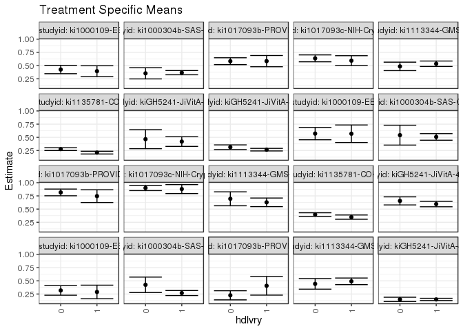

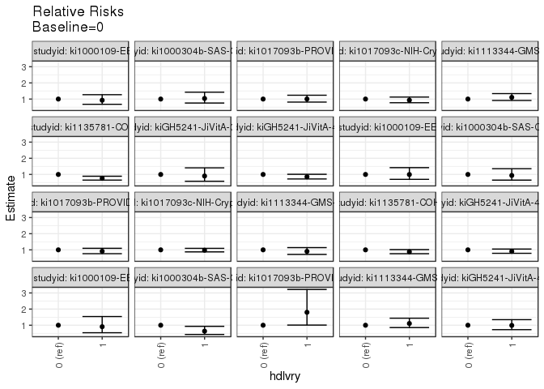

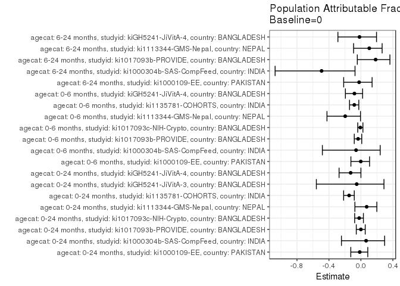

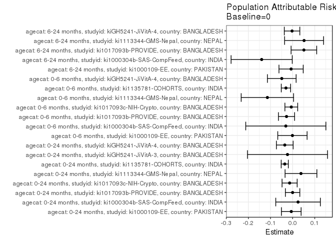

## Results Table

### Parameter: TSM

| agecat | studyid | country | intervention_level | baseline_level | estimate | ci_lower | ci_upper |
| --- | --- | --- | --- | --- | --- | --- | --- |
| 0-24 months | ki1000109-EE | PAKISTAN | 0 | NA | 0.4257534 | 0.3465593 | 0.5049476 |
| 0-24 months | ki1000109-EE | PAKISTAN | 1 | NA | 0.3941301 | 0.2912233 | 0.4970369 |
| 0-24 months | ki1000304b-SAS-CompFeed | INDIA | 0 | NA | 0.3532483 | 0.2475815 | 0.4589151 |
| 0-24 months | ki1000304b-SAS-CompFeed | INDIA | 1 | NA | 0.3660614 | 0.3260972 | 0.4060255 |
| 0-24 months | ki1017093b-PROVIDE | BANGLADESH | 0 | NA | 0.5832111 | 0.5179810 | 0.6484412 |
| 0-24 months | ki1017093b-PROVIDE | BANGLADESH | 1 | NA | 0.5847793 | 0.4785151 | 0.6910434 |
| 0-24 months | ki1017093c-NIH-Crypto | BANGLADESH | 0 | NA | 0.6374064 | 0.5720048 | 0.7028080 |
| 0-24 months | ki1017093c-NIH-Crypto | BANGLADESH | 1 | NA | 0.5934056 | 0.4996093 | 0.6872019 |
| 0-24 months | ki1113344-GMS-Nepal | NEPAL | 0 | NA | 0.4847078 | 0.4043513 | 0.5650642 |
| 0-24 months | ki1113344-GMS-Nepal | NEPAL | 1 | NA | 0.5349624 | 0.4836373 | 0.5862875 |
| 0-24 months | ki1135781-COHORTS | INDIA | 0 | NA | 0.2769775 | 0.2505024 | 0.3034525 |
| 0-24 months | ki1135781-COHORTS | INDIA | 1 | NA | 0.2106242 | 0.1845055 | 0.2367429 |
| 0-24 months | kiGH5241-JiVitA-3 | BANGLADESH | 0 | NA | 0.4651103 | 0.2850769 | 0.6451436 |
| 0-24 months | kiGH5241-JiVitA-3 | BANGLADESH | 1 | NA | 0.4199319 | 0.3285018 | 0.5113620 |
| 0-24 months | kiGH5241-JiVitA-4 | BANGLADESH | 0 | NA | 0.3125703 | 0.2682298 | 0.3569107 |
| 0-24 months | kiGH5241-JiVitA-4 | BANGLADESH | 1 | NA | 0.2665663 | 0.2424694 | 0.2906632 |
| 0-6 months | ki1000109-EE | PAKISTAN | 0 | NA | 0.5710354 | 0.4538076 | 0.6882632 |
| 0-6 months | ki1000109-EE | PAKISTAN | 1 | NA | 0.5681502 | 0.4023337 | 0.7339667 |
| 0-6 months | ki1000304b-SAS-CompFeed | INDIA | 0 | NA | 0.5416530 | 0.3534377 | 0.7298682 |
| 0-6 months | ki1000304b-SAS-CompFeed | INDIA | 1 | NA | 0.5078753 | 0.4454753 | 0.5702753 |
| 0-6 months | ki1017093b-PROVIDE | BANGLADESH | 0 | NA | 0.8156795 | 0.7518685 | 0.8794906 |
| 0-6 months | ki1017093b-PROVIDE | BANGLADESH | 1 | NA | 0.7453698 | 0.6246178 | 0.8661219 |
| 0-6 months | ki1017093c-NIH-Crypto | BANGLADESH | 0 | NA | 0.9000000 | 0.8497106 | 0.9502894 |
| 0-6 months | ki1017093c-NIH-Crypto | BANGLADESH | 1 | NA | 0.8793103 | 0.7944001 | 0.9642206 |
| 0-6 months | ki1113344-GMS-Nepal | NEPAL | 0 | NA | 0.6949892 | 0.5627304 | 0.8272479 |
| 0-6 months | ki1113344-GMS-Nepal | NEPAL | 1 | NA | 0.6280148 | 0.5466693 | 0.7093604 |
| 0-6 months | ki1135781-COHORTS | INDIA | 0 | NA | 0.3961124 | 0.3619056 | 0.4303191 |
| 0-6 months | ki1135781-COHORTS | INDIA | 1 | NA | 0.3479130 | 0.3074807 | 0.3883454 |
| 0-6 months | kiGH5241-JiVitA-4 | BANGLADESH | 0 | NA | 0.6550383 | 0.5785991 | 0.7314775 |
| 0-6 months | kiGH5241-JiVitA-4 | BANGLADESH | 1 | NA | 0.5949162 | 0.5441056 | 0.6457267 |
| 6-24 months | ki1000109-EE | PAKISTAN | 0 | NA | 0.3177764 | 0.2275852 | 0.4079676 |
| 6-24 months | ki1000109-EE | PAKISTAN | 1 | NA | 0.2888306 | 0.1599455 | 0.4177157 |
| 6-24 months | ki1000304b-SAS-CompFeed | INDIA | 0 | NA | 0.4246645 | 0.2786374 | 0.5706915 |
| 6-24 months | ki1000304b-SAS-CompFeed | INDIA | 1 | NA | 0.2689626 | 0.2212821 | 0.3166430 |
| 6-24 months | ki1017093b-PROVIDE | BANGLADESH | 0 | NA | 0.2255057 | 0.1391151 | 0.3118964 |
| 6-24 months | ki1017093b-PROVIDE | BANGLADESH | 1 | NA | 0.4061663 | 0.2294011 | 0.5829315 |
| 6-24 months | ki1113344-GMS-Nepal | NEPAL | 0 | NA | 0.4424762 | 0.3426642 | 0.5422883 |
| 6-24 months | ki1113344-GMS-Nepal | NEPAL | 1 | NA | 0.4907340 | 0.4282194 | 0.5532485 |
| 6-24 months | kiGH5241-JiVitA-4 | BANGLADESH | 0 | NA | 0.1491812 | 0.1088361 | 0.1895262 |
| 6-24 months | kiGH5241-JiVitA-4 | BANGLADESH | 1 | NA | 0.1476819 | 0.1261367 | 0.1692270 |

### Parameter: E(Y)

| agecat | studyid | country | intervention_level | baseline_level | estimate | ci_lower | ci_upper |
| --- | --- | --- | --- | --- | --- | --- | --- |
| 0-24 months | ki1000109-EE | PAKISTAN | NA | NA | 0.4196078 | 0.3541827 | 0.4850330 |
| 0-24 months | ki1000304b-SAS-CompFeed | INDIA | NA | NA | 0.3777778 | 0.3394240 | 0.4161316 |
| 0-24 months | ki1017093b-PROVIDE | BANGLADESH | NA | NA | 0.5830619 | 0.5262762 | 0.6398476 |
| 0-24 months | ki1017093c-NIH-Crypto | BANGLADESH | NA | NA | 0.6237942 | 0.5698223 | 0.6777662 |
| 0-24 months | ki1113344-GMS-Nepal | NEPAL | NA | NA | 0.5224172 | 0.4758292 | 0.5690051 |
| 0-24 months | ki1135781-COHORTS | INDIA | NA | NA | 0.2413610 | 0.2219406 | 0.2607813 |
| 0-24 months | kiGH5241-JiVitA-3 | BANGLADESH | NA | NA | 0.4418605 | 0.3551361 | 0.5285849 |
| 0-24 months | kiGH5241-JiVitA-4 | BANGLADESH | NA | NA | 0.2770745 | 0.2555719 | 0.2985771 |
| 0-6 months | ki1000109-EE | PAKISTAN | NA | NA | 0.5700935 | 0.4742263 | 0.6659606 |
| 0-6 months | ki1000304b-SAS-CompFeed | INDIA | NA | NA | 0.5107914 | 0.4514901 | 0.5700927 |
| 0-6 months | ki1017093b-PROVIDE | BANGLADESH | NA | NA | 0.7880435 | 0.7295878 | 0.8464992 |
| 0-6 months | ki1017093c-NIH-Crypto | BANGLADESH | NA | NA | 0.8939394 | 0.8505280 | 0.9373508 |
| 0-6 months | ki1113344-GMS-Nepal | NEPAL | NA | NA | 0.5808383 | 0.5055058 | 0.6561709 |
| 0-6 months | ki1135781-COHORTS | INDIA | NA | NA | 0.3658340 | 0.3390250 | 0.3926430 |
| 0-6 months | kiGH5241-JiVitA-4 | BANGLADESH | NA | NA | 0.6059406 | 0.5632798 | 0.6486014 |
| 6-24 months | ki1000109-EE | PAKISTAN | NA | NA | 0.3108108 | 0.2352987 | 0.3863229 |
| 6-24 months | ki1000304b-SAS-CompFeed | INDIA | NA | NA | 0.2846348 | 0.2390527 | 0.3302168 |
| 6-24 months | ki1017093b-PROVIDE | BANGLADESH | NA | NA | 0.2764228 | 0.1950773 | 0.3577682 |
| 6-24 months | ki1113344-GMS-Nepal | NEPAL | NA | NA | 0.4942197 | 0.4375393 | 0.5509000 |
| 6-24 months | kiGH5241-JiVitA-4 | BANGLADESH | NA | NA | 0.1465619 | 0.1273484 | 0.1657754 |

### Parameter: RR

| agecat | studyid | country | intervention_level | baseline_level | estimate | ci_lower | ci_upper |
| --- | --- | --- | --- | --- | --- | --- | --- |
| 0-24 months | ki1000109-EE | PAKISTAN | 0 | 0 | 1.0000000 | 1.0000000 | 1.0000000 |
| 0-24 months | ki1000109-EE | PAKISTAN | 1 | 0 | 0.9257238 | 0.6750531 | 1.2694773 |
| 0-24 months | ki1000304b-SAS-CompFeed | INDIA | 0 | 0 | 1.0000000 | 1.0000000 | 1.0000000 |
| 0-24 months | ki1000304b-SAS-CompFeed | INDIA | 1 | 0 | 1.0362721 | 0.7536555 | 1.4248684 |
| 0-24 months | ki1017093b-PROVIDE | BANGLADESH | 0 | 0 | 1.0000000 | 1.0000000 | 1.0000000 |
| 0-24 months | ki1017093b-PROVIDE | BANGLADESH | 1 | 0 | 1.0026890 | 0.8129555 | 1.2367039 |
| 0-24 months | ki1017093c-NIH-Crypto | BANGLADESH | 0 | 0 | 1.0000000 | 1.0000000 | 1.0000000 |
| 0-24 months | ki1017093c-NIH-Crypto | BANGLADESH | 1 | 0 | 0.9309689 | 0.7711500 | 1.1239098 |
| 0-24 months | ki1113344-GMS-Nepal | NEPAL | 0 | 0 | 1.0000000 | 1.0000000 | 1.0000000 |
| 0-24 months | ki1113344-GMS-Nepal | NEPAL | 1 | 0 | 1.1036803 | 0.9113127 | 1.3366544 |
| 0-24 months | ki1135781-COHORTS | INDIA | 0 | 0 | 1.0000000 | 1.0000000 | 1.0000000 |
| 0-24 months | ki1135781-COHORTS | INDIA | 1 | 0 | 0.7604380 | 0.6504494 | 0.8890252 |
| 0-24 months | kiGH5241-JiVitA-3 | BANGLADESH | 0 | 0 | 1.0000000 | 1.0000000 | 1.0000000 |
| 0-24 months | kiGH5241-JiVitA-3 | BANGLADESH | 1 | 0 | 0.9028653 | 0.5783373 | 1.4094989 |
| 0-24 months | kiGH5241-JiVitA-4 | BANGLADESH | 0 | 0 | 1.0000000 | 1.0000000 | 1.0000000 |
| 0-24 months | kiGH5241-JiVitA-4 | BANGLADESH | 1 | 0 | 0.8528203 | 0.7207796 | 1.0090498 |
| 0-6 months | ki1000109-EE | PAKISTAN | 0 | 0 | 1.0000000 | 1.0000000 | 1.0000000 |
| 0-6 months | ki1000109-EE | PAKISTAN | 1 | 0 | 0.9949474 | 0.6967228 | 1.4208238 |
| 0-6 months | ki1000304b-SAS-CompFeed | INDIA | 0 | 0 | 1.0000000 | 1.0000000 | 1.0000000 |
| 0-6 months | ki1000304b-SAS-CompFeed | INDIA | 1 | 0 | 0.9376397 | 0.6485928 | 1.3555010 |
| 0-6 months | ki1017093b-PROVIDE | BANGLADESH | 0 | 0 | 1.0000000 | 1.0000000 | 1.0000000 |
| 0-6 months | ki1017093b-PROVIDE | BANGLADESH | 1 | 0 | 0.9138023 | 0.7629395 | 1.0944966 |
| 0-6 months | ki1017093c-NIH-Crypto | BANGLADESH | 0 | 0 | 1.0000000 | 1.0000000 | 1.0000000 |
| 0-6 months | ki1017093c-NIH-Crypto | BANGLADESH | 1 | 0 | 0.9770115 | 0.8738707 | 1.0923258 |
| 0-6 months | ki1113344-GMS-Nepal | NEPAL | 0 | 0 | 1.0000000 | 1.0000000 | 1.0000000 |
| 0-6 months | ki1113344-GMS-Nepal | NEPAL | 1 | 0 | 0.9036325 | 0.7173696 | 1.1382582 |
| 0-6 months | ki1135781-COHORTS | INDIA | 0 | 0 | 1.0000000 | 1.0000000 | 1.0000000 |
| 0-6 months | ki1135781-COHORTS | INDIA | 1 | 0 | 0.8783190 | 0.7600569 | 1.0149823 |
| 0-6 months | kiGH5241-JiVitA-4 | BANGLADESH | 0 | 0 | 1.0000000 | 1.0000000 | 1.0000000 |
| 0-6 months | kiGH5241-JiVitA-4 | BANGLADESH | 1 | 0 | 0.9082158 | 0.7859873 | 1.0494521 |
| 6-24 months | ki1000109-EE | PAKISTAN | 0 | 0 | 1.0000000 | 1.0000000 | 1.0000000 |
| 6-24 months | ki1000109-EE | PAKISTAN | 1 | 0 | 0.9089113 | 0.5365721 | 1.5396248 |
| 6-24 months | ki1000304b-SAS-CompFeed | INDIA | 0 | 0 | 1.0000000 | 1.0000000 | 1.0000000 |
| 6-24 months | ki1000304b-SAS-CompFeed | INDIA | 1 | 0 | 0.6333532 | 0.4301064 | 0.9326441 |
| 6-24 months | ki1017093b-PROVIDE | BANGLADESH | 0 | 0 | 1.0000000 | 1.0000000 | 1.0000000 |
| 6-24 months | ki1017093b-PROVIDE | BANGLADESH | 1 | 0 | 1.8011354 | 1.0094566 | 3.2136979 |
| 6-24 months | ki1113344-GMS-Nepal | NEPAL | 0 | 0 | 1.0000000 | 1.0000000 | 1.0000000 |
| 6-24 months | ki1113344-GMS-Nepal | NEPAL | 1 | 0 | 1.1090629 | 0.8561279 | 1.4367252 |
| 6-24 months | kiGH5241-JiVitA-4 | BANGLADESH | 0 | 0 | 1.0000000 | 1.0000000 | 1.0000000 |
| 6-24 months | kiGH5241-JiVitA-4 | BANGLADESH | 1 | 0 | 0.9899497 | 0.7280476 | 1.3460666 |

### Parameter: PAR

| agecat | studyid | country | intervention_level | baseline_level | estimate | ci_lower | ci_upper |
| --- | --- | --- | --- | --- | --- | --- | --- |
| 0-24 months | ki1000109-EE | PAKISTAN | 0 | NA | -0.0061456 | -0.0506474 | 0.0383562 |
| 0-24 months | ki1000304b-SAS-CompFeed | INDIA | 0 | NA | 0.0245295 | -0.0762902 | 0.1253492 |
| 0-24 months | ki1017093b-PROVIDE | BANGLADESH | 0 | NA | -0.0001492 | -0.0327594 | 0.0324611 |
| 0-24 months | ki1017093c-NIH-Crypto | BANGLADESH | 0 | NA | -0.0136122 | -0.0477738 | 0.0205494 |
| 0-24 months | ki1113344-GMS-Nepal | NEPAL | 0 | NA | 0.0377094 | -0.0341755 | 0.1095943 |
| 0-24 months | ki1135781-COHORTS | INDIA | 0 | NA | -0.0356165 | -0.0517224 | -0.0195106 |
| 0-24 months | kiGH5241-JiVitA-3 | BANGLADESH | 0 | NA | -0.0232498 | -0.2042391 | 0.1577395 |
| 0-24 months | kiGH5241-JiVitA-4 | BANGLADESH | 0 | NA | -0.0354958 | -0.0733331 | 0.0023416 |
| 0-6 months | ki1000109-EE | PAKISTAN | 0 | NA | -0.0009420 | -0.0672763 | 0.0653924 |
| 0-6 months | ki1000304b-SAS-CompFeed | INDIA | 0 | NA | -0.0308616 | -0.2120275 | 0.1503043 |
| 0-6 months | ki1017093b-PROVIDE | BANGLADESH | 0 | NA | -0.0276360 | -0.0641430 | 0.0088709 |
| 0-6 months | ki1017093c-NIH-Crypto | BANGLADESH | 0 | NA | -0.0060606 | -0.0350005 | 0.0228793 |
| 0-6 months | ki1113344-GMS-Nepal | NEPAL | 0 | NA | -0.1141508 | -0.2326090 | 0.0043073 |
| 0-6 months | ki1135781-COHORTS | INDIA | 0 | NA | -0.0302783 | -0.0514015 | -0.0091552 |
| 0-6 months | kiGH5241-JiVitA-4 | BANGLADESH | 0 | NA | -0.0490977 | -0.1139842 | 0.0157887 |
| 6-24 months | ki1000109-EE | PAKISTAN | 0 | NA | -0.0069656 | -0.0617989 | 0.0478676 |
| 6-24 months | ki1000304b-SAS-CompFeed | INDIA | 0 | NA | -0.1400297 | -0.2782662 | -0.0017932 |
| 6-24 months | ki1017093b-PROVIDE | BANGLADESH | 0 | NA | 0.0509170 | -0.0069629 | 0.1087969 |
| 6-24 months | ki1113344-GMS-Nepal | NEPAL | 0 | NA | 0.0517434 | -0.0363807 | 0.1398675 |
| 6-24 months | kiGH5241-JiVitA-4 | BANGLADESH | 0 | NA | -0.0026193 | -0.0377051 | 0.0324665 |

### Parameter: PAF

| agecat | studyid | country | intervention_level | baseline_level | estimate | ci_lower | ci_upper |
| --- | --- | --- | --- | --- | --- | --- | --- |
| 0-24 months | ki1000109-EE | PAKISTAN | 0 | NA | -0.0146461 | -0.1264653 | 0.0860734 |
| 0-24 months | ki1000304b-SAS-CompFeed | INDIA | 0 | NA | 0.0649310 | -0.2435011 | 0.2968610 |
| 0-24 months | ki1017093b-PROVIDE | BANGLADESH | 0 | NA | -0.0002558 | -0.0577786 | 0.0541388 |
| 0-24 months | ki1017093c-NIH-Crypto | BANGLADESH | 0 | NA | -0.0218216 | -0.0780077 | 0.0314359 |
| 0-24 months | ki1113344-GMS-Nepal | NEPAL | 0 | NA | 0.0721825 | -0.0753363 | 0.1994642 |
| 0-24 months | ki1135781-COHORTS | INDIA | 0 | NA | -0.1475652 | -0.2160972 | -0.0828952 |
| 0-24 months | kiGH5241-JiVitA-3 | BANGLADESH | 0 | NA | -0.0526180 | -0.5573504 | 0.2885323 |
| 0-24 months | kiGH5241-JiVitA-4 | BANGLADESH | 0 | NA | -0.1281090 | -0.2731902 | 0.0004400 |
| 0-6 months | ki1000109-EE | PAKISTAN | 0 | NA | -0.0016523 | -0.1250337 | 0.1081980 |
| 0-6 months | ki1000304b-SAS-CompFeed | INDIA | 0 | NA | -0.0604192 | -0.4821282 | 0.2413012 |
| 0-6 months | ki1017093b-PROVIDE | BANGLADESH | 0 | NA | -0.0350692 | -0.0829535 | 0.0106979 |
| 0-6 months | ki1017093c-NIH-Crypto | BANGLADESH | 0 | NA | -0.0067797 | -0.0397071 | 0.0251050 |
| 0-6 months | ki1113344-GMS-Nepal | NEPAL | 0 | NA | -0.1965277 | -0.4244695 | -0.0050609 |
| 0-6 months | ki1135781-COHORTS | INDIA | 0 | NA | -0.0827653 | -0.1423781 | -0.0262632 |
| 0-6 months | kiGH5241-JiVitA-4 | BANGLADESH | 0 | NA | -0.0810273 | -0.1939746 | 0.0212355 |
| 6-24 months | ki1000109-EE | PAKISTAN | 0 | NA | -0.0224111 | -0.2155146 | 0.1400148 |
| 6-24 months | ki1000304b-SAS-CompFeed | INDIA | 0 | NA | -0.4919627 | -1.0736298 | -0.0734572 |
| 6-24 months | ki1017093b-PROVIDE | BANGLADESH | 0 | NA | 0.1841999 | -0.0448237 | 0.3630219 |
| 6-24 months | ki1113344-GMS-Nepal | NEPAL | 0 | NA | 0.1046972 | -0.0916095 | 0.2657016 |
| 6-24 months | kiGH5241-JiVitA-4 | BANGLADESH | 0 | NA | -0.0178716 | -0.2877119 | 0.1954236 |